# Glaciation

Dr. Ahmad Redaa

2025-03-05

# Glacial Periods in Earth’s History

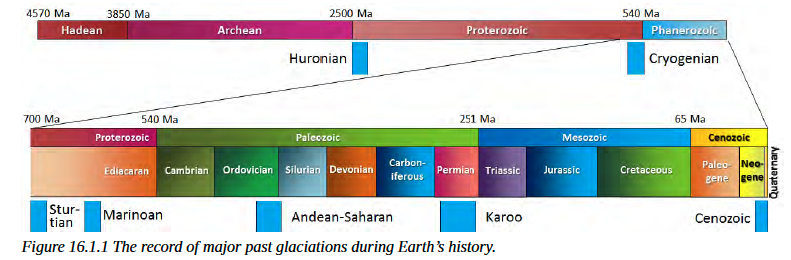

Source: [Steven, E. (2015)](https://openlibrary-repo.ecampusontario.ca/jspui/handle/123456789/402)

## Major Glaciations

- **Huronian Glaciation (2.4 - 2.1 Ga)**: One of the earliest recorded glaciations.
- **Cryogenian “Snowball Earth” (700 - 650 Ma)**: Period of global-scale glaciation.
- **Phanerozoic Glaciations**:
  - Andean/Saharan (450 - 420 Ma)
  - Karoo (360 - 260 Ma)
  - Cenozoic (34 Ma - Present)

## Pleistocene Glaciation

- Cycles of glacial and interglacial periods driven by **Milankovitch Cycles**.
- **Last Glacial Maximum (20 ka)**: Ice sheets covered ~30% of land.

# Causes of Glaciation

- Tectonic activity (e.g., Himalayan uplift) increased erosion and removed CO₂, cooling the climate.
- Changes in ocean currents (e.g., the Antarctic Circumpolar Current) isolated polar regions, leading to glaciation.
- Milankovitch Cycles (changes in Earth’s orbit and tilt) regulate glacial-interglacial cycles.

# How Glaciers Work

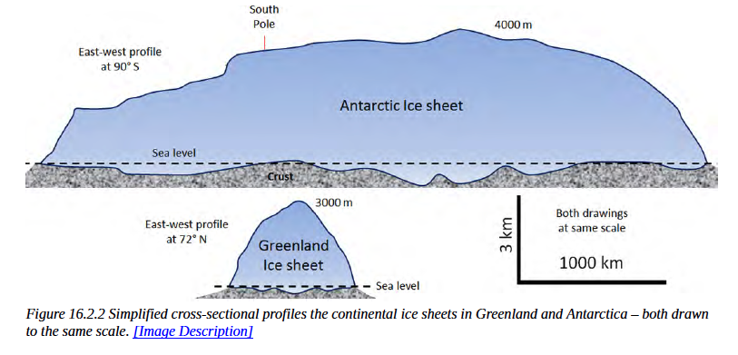

Source: [Steven, E. (2015)](https://openlibrary-repo.ecampusontario.ca/jspui/handle/123456789/402)

## Types of Glaciers

- **Continental Glaciers**: Cover vast land areas (Antarctica, Greenland).
- **Alpine Glaciers**: Found in mountainous regions.

# Glacier Formation & Movement

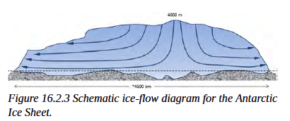

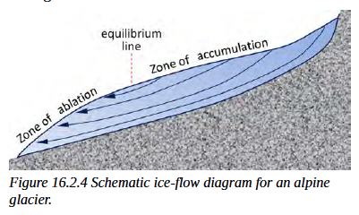

Source: [Steven, E. (2015)](https://openlibrary-repo.ecampusontario.ca/jspui/handle/123456789/402)

- **Glacier:** A mass of ice that moves under its own weight.
- Forms when accumulated snow compacts into firn, then glacial ice.
- **Equilibrium Line:** The boundary between the zone of accumulation and the zone of ablation.
- **Glacial advance:** More accumulation than melting.
- **Glacial retreat:** More melting than accumulation.
- **Ice Flow Mechanisms**:
  - **Internal Flow**: Ice deforms plastically under pressure.
  - **Basal Sliding**: If water is present at the base, ice slides over the bedrock.
  - **Crevasses:** Surface cracks due to differential movement.

# Glacial Erosion

## How Glaciers Erode

- Glacial ice alone does not erode effectively; embedded rock fragments act like sandpaper.
- Plucking: Ice pulls away chunks of bedrock.
- Abrasion: Rock fragments scrape and polish surfaces.

# Erosional Features

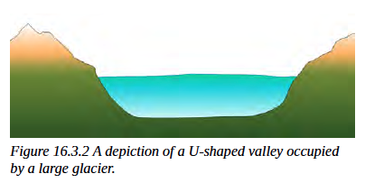

Source: [Steven, E. (2015)](https://openlibrary-repo.ecampusontario.ca/jspui/handle/123456789/402)

- **Alpine Glacial Features**
  - **U-Shaped Valleys**: Deep valleys with steep walls, carved by glaciers as they move.
  - **Arêtes:** Sharp ridges between glacial valleys.
  - **Horns:** Steep, pyramid-like peaks.
  - **Cirques:** Bowl-shaped depressions where glaciers form.
  - **Hanging Valleys:** Tributary valleys left at higher elevations.
  - **Truncated Spurs:** Ridges cut off by glacier erosion.
- **Continental Glacial Features**
  - **Drumlins:** Streamlined hills shaped by glaciers.
  - **Roches Moutonées:** Asymmetrical rock features smoothed by ice.
  - **Glacial Striations:** Grooves carved by moving glaciers.

# Alpine Glacial Features

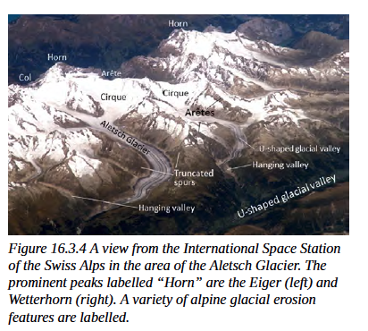

Source: [Steven, E. (2015)](https://openlibrary-repo.ecampusontario.ca/jspui/handle/123456789/402)

# Factors Affecting Erosion

- Ice thickness, slope, presence of rock fragments.

# Glacial Deposition

## How Glaciers Deposit Material

- **Till:** Unsorted sediments deposited directly by glaciers.
  - **Lodgement Till**: Compacted beneath the glacier.
  - **Ablation Till**: Deposited from melting ice.
- **Glaciofluvial Deposits:** Sorted sediments deposited by meltwater.
- **Glaciolacustrine Deposits:** Sediments deposited in glacial lakes.
- **Glaciomarine Deposits:** Sediments deposited in the ocean from icebergs.

# Landforms Created by Glacial Deposition

- **Moraines:** Ridges of till deposited at glacier edges.
- **Eskers:** Sinuous ridges formed by subglacial rivers.
- **Kettles & Kettle Lakes:** Depressions formed by melting ice blocks.
- **Outwash Plains (Sandurs):** Extensive sediment deposits from glacial meltwater.

## Depositional Features

- **Moraines**: Ridges of till.
- **Drumlins**: Streamlined hills from ice movement.
- **Kettle Lakes**: Formed by melting ice blocks.

# Glacial Lakes

- **Tarns:** Cirque lakes.
- **Finger Lakes:** Long, narrow lakes in glacial valleys.
- **Moraine Lakes:** Formed behind moraines.
- **Kettle Lakes:** Small depressions filled with meltwater.

# Summary

- Glaciation has shaped Earth’s landscape through erosion and deposition.
- Glaciers are dynamic systems influenced by climate and topography.
- Understanding glacial processes helps reconstruct past climates and landscapes.